Tài liệu này mang giấy phép Creative Commons Attribution (CC BY). (c) Nguyễn Ngọc Sáng, Zhukovsky 12/2018.

[@SangVn](https://github.com/SangVn) [@VnCFD](https://vncfdgroup.wordpress.com/)

*Thực hành CFD với Python!*

# Bài 15. So sánh sơ đồ Godunov, MUSCL, WENO5

Như vậy ta đã thực hành giải phương trình Burgers với ba sơ đồ Godunov bậc 1, MUSCL bậc hai và WENO5 bậc 5. Ở bài này trước hết các bạn hãy tổng hợp ba sơ đồ trên vào một module gọi là **burgers_solver** chứa trong thư mục **lib**. Để gọi module burgers_solver, ta cần tạo một file rỗng với tên là $__init__.py$ trong lib.

Bây giờ ta sẽ sử dụng module này để giải bài toán `Zalesak` với điều kiện ban đầu là bốn đỉnh tháp liên tiếp: nhọn, vuông, nhọn, tù.

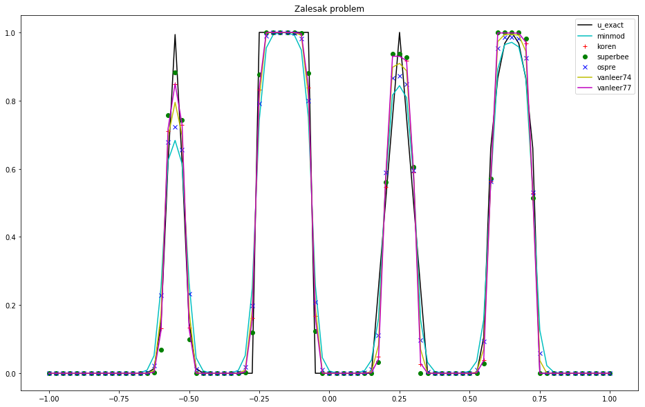

```python
#import thư viện, module
import matplotlib.pyplot as plt
from lib.burgers_solver import*

#lưới và thông số tính toán
nx = 81
x, dx = np.linspace(-1, 1, nx, retstep=True)
r = 0.4
dt = r*dx
nt = 15

#Bài toán Zalesak
a = 0.5
z = -0.7
delta = 0.005
alpha = 10.
beta = np.log(2.)/(36*delta**2)

def G(x, z):
    return np.exp(-beta*(x-z)**2)

def F(x, a):
    return np.sqrt(abs(1-alpha**2*(x-a)**2))

#điều kiện ban đầu
u0 = np.zeros(nx)
for i, xi in enumerate(x):
    if (-0.8 <= xi <= -0.6): u0[i] = 1./6*(G(xi, z-delta) + G(xi, z+delta) + 4*G(xi, z))
    elif (-0.4 <= xi <= -0.2): u0[i] = 1.
    elif (0 <= xi <= 0.2): u0[i] = 1 - abs(10*(xi-0.1))
    elif (0.4 <= xi <= 0.6): u0[i] = 1./6*(F(xi, a-delta) + F(xi, a+delta) + 4*F(xi,a))

#xét phương trình chuyển dịch tuyến tính du/dt + du/dx = 0
def flux(u):
    return u

#nghiệm chính xác
i = int(nt*dt/dx)
u_exact = np.roll(u0, i) #dịch chuyển sang phải i bước

#trước hết ta so sánh các giới hạn độ dốc trong MUSCL
u_mm = u0.copy()
u_kr = u0.copy()
u_sb = u0.copy()
u_op = u0.copy()
u_vl74 = u0.copy()
u_vl77 = u0.copy()

muscl(u_mm, minmod, flux, dx, dt, nt)
muscl(u_kr, koren, flux, dx, dt, nt)
muscl(u_sb, superbee, flux, dx, dt, nt)
muscl(u_op, ospre, flux, dx, dt, nt)
muscl(u_vl74, vanleer74, flux, dx, dt, nt)
muscl(u_vl77, vanleer77, flux, dx, dt, nt)


fig = plt.figure(figsize=[16, 10])
plt.plot(x, u_exact, 'k', x, u_mm, 'c', x, u_kr, 'r+', x, u_sb, 'go',)
plt.plot(x, u_op, 'bx', x, u_vl74, 'y', x, u_vl77, 'm')
plt.legend(['u_exact', 'minmod', 'koren', 'superbee', 'ospre', 'vanleer74', 'vanleer77'])
plt.title('Zalesak problem')
plt.show()
```

Với 4 đỉnh tháp liên tiếp: nhọn - vuông - nhọn - tù, các sơ đồ đã phần nào bộc lộ khả năng của mình. Tuy nhiên khá là khó để đưa ra kết luận cuối cùng cái nào tốt nhất. Xét theo độ cao và hình dạng tháp, ta có thể lựa chọn sơ đồ `ospre` hoặc vanleer74 để so sánh với các phương pháp còn lại.

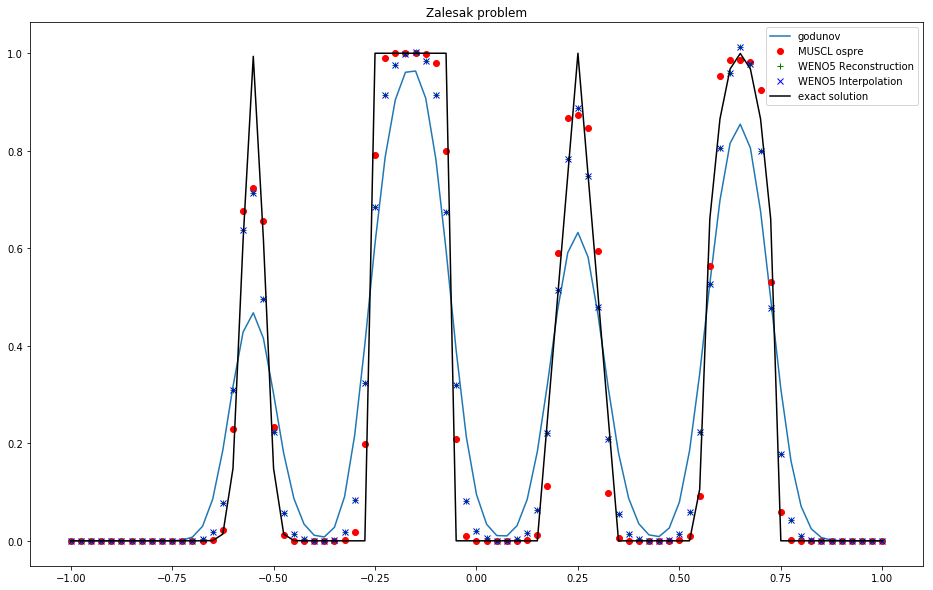

```python
#sơ đồ godunov và weno5
u_godunov = u0.copy()
godunov(u_godunov, flux, dx, dt, nt)

u_weno5_rct = u0.copy()
weno5_reconstruction(u_weno5_rct, flux, dx, dt, nt)

u_weno5_ipt = u0.copy()
weno5_reconstruction(u_weno5_ipt, flux, dx, dt, nt)

fig = plt.figure(figsize=[16, 10])
plt.plot(x, u_godunov, x, u_op, 'ro', x, u_weno5_rct, 'g+')
plt.plot(x, u_weno5_ipt, 'bx', x, u_exact, 'k')
plt.legend(['godunov', 'MUSCL ospre', 'WENO5 Reconstruction', 'WENO5 Interpolation', 'exact solution'])
plt.title('Zalesak problem')
plt.show()
```

Ta thấy sơ đồ Godunov cho kết quả kém nhất. Hai sơ đồ WENO5 cho kết quả như nhau. Kết quả thu được bằng phương pháp WENO5 và MUSCL khá giống nhau. Sơ đồ MUSCL chiếm ưu thế tại các chân tháp và đỉnh tháp vuông - những vị trí gián đoạn, còn WENO5 chiếm đỉnh tháp nhọn và tù - vị trí cực đại. Tiếp theo ta giải bài toán chuyển dịch không tuyến tính.

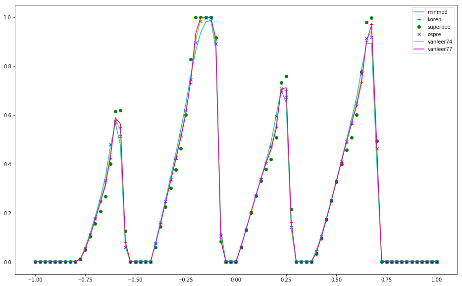

```python
#xét phương trình chuyển dịch tuyến tính du/dt + udu/dx = 0
def flux(u):
    return u**2/2.

#không có nghiệm chính xác

#trước hết ta chọn so sánh các giới hạn độ dốc trong MUSCL
u_mm = u0.copy()
u_kr = u0.copy()
u_sb = u0.copy()
u_op = u0.copy()
u_vl74 = u0.copy()
u_vl77 = u0.copy()

nt = 25

muscl(u_mm, minmod, flux, dx, dt, nt)
muscl(u_kr, koren, flux, dx, dt, nt)
muscl(u_sb, superbee, flux, dx, dt, nt)
muscl(u_op, ospre, flux, dx, dt, nt)
muscl(u_vl74, vanleer74, flux, dx, dt, nt)
muscl(u_vl77, vanleer77, flux, dx, dt, nt)


fig = plt.figure(figsize=[16, 10])
plt.plot(x, u_mm, 'c', x, u_kr, 'r+', x, u_sb, 'go',)
plt.plot(x, u_op, 'bx', x, u_vl74, 'y', x, u_vl77, 'm')
plt.legend([ 'minmod', 'koren', 'superbee', 'ospre', 'vanleer74', 'vanleer77'])
plt.show()
```

Ở đây không có nghiệm chính xác để so sánh, căn cứ theo hình dạng các đỉnh tháp, ta có thể chọn sơ đồ vanleer77 để so sánh với weno5 và godunov.

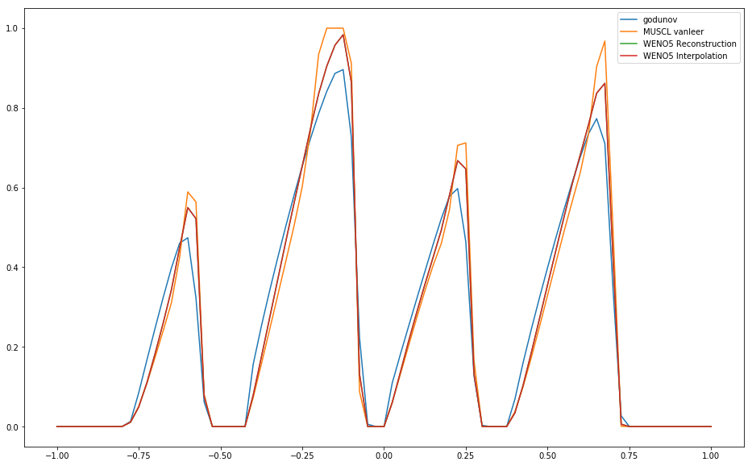

```python
#sơ đồ godunov và weno5
u_godunov = u0.copy()
godunov(u_godunov, flux, dx, dt, nt)

u_weno5_rct = u0.copy()
weno5_reconstruction(u_weno5_rct, flux, dx, dt, nt)

u_weno5_ipt = u0.copy()
weno5_reconstruction(u_weno5_ipt, flux, dx, dt, nt)

fig = plt.figure(figsize=[16, 10])
plt.plot(x, u_godunov, x, u_vl77, x, u_weno5_rct, x, u_weno5_ipt)
plt.legend(['godunov', 'MUSCL vanleer', 'WENO5 Reconstruction', 'WENO5 Interpolation'])
plt.show()
```

Sơ đồ Godunov thường cho `hình dạng phù hợp` (vuông tròn méo) với kết quả chính xác. Trên cơ sở đó ta thấy sơ đồ WENO5 cho hình dạng các tháp phù hợp hơn sơ đồ MUSCL.

Các bạn hãy tìm thêm các bài toán và so sánh hai phương pháp nhằm đánh giá cụ thể hơn.

Như vậy ta đã làm quen với ba sơ đồ cơ bản **Godunov, MUSCL và WENO5** cũng như phương pháp **Runge-Kutta**. Ở các bài tiếp theo ta sẽ áp dụng ba loại sơ đồ này để giải bài toán động lực học lưu chất, bắt đầu với sơ đồ Euler một chiều.

### Bài 16. Hệ phương trình Euler, bài toán Riemann, phân rã gián đoạn Godunov